# Qiime2: Getting started

ANSC595

2/16/2021

## Qiime2 tutorials

There are many qiime2 tutorials. I would direct you to https://docs.qiime2.org/2020.11/ to get the official documentation. Another pretty good reference is this presentation http://compbio.ucsd.edu/wp-content/uploads/2016/10/20170712_microbiome_16s_tutorial_non-interactive.pdf

### Getting started

They recommend starting with the grand overview and Moving Pictures (single-end data) tutorial, followed by the FMT study and Atacama Desert soils (paired-end data) tutorials.

### What is qiime2

End to end microbiome analysis pipeline. It is a complete rewrite of qiime1 and fixes many of the qiime1 bugs. Its progress. Key improved features include

- Integrated and automatic racking of data provenance
- Semantic type system
- Plugin system for extending microbiome analysis functionality
- Support for multiple types of user interfaces (e.g. API, command line, graphical)

### Core Concepts

#### 1. Data files: artifacts

- Artifacts are good.
- They contain data and metadata.
- Think archeological artifact.
- You create your first artifact by importing data.
- Qiime will create artifacts from artifacts.
- Artifacts enable the data provenance process
- These files have the suffix `.qza`
- These files are not easily readable. They are zipped files that are transportable. If you want to see the contents you can unzip them (`unzip -k file.qza) and look through the`data/` folder

#### 2. Data files: visualizations

- Contain the endpoint important files (terminal outputs)
- Also contain metadata and provenance
- Can be viewed but not at the command line. Must use the website `https://view.qiime2.org`

#### 3. Semantic types

- An attempt to prevent people from using the wrong data as input to a process.

#### 4. Methods and visualizers

- `methods` takes an artifact as input and produces artifacts as output
- `visualizers` take an artifact as input and produces one visualization file as output.
- visualization files cannot be used as input.

## Conceptual overview of qiime

The qiime developers have done their work to try to explain the qiime analysis pipeline and what happens. They have many great explanations available here: https://docs.qiime2.org/2019.1/tutorials/overview/ and here https://docs.qiime2.org/2019.1/tutorials/qiime2-for-experienced-microbiome-researchers/

They have many flowcharts to breakdown what happens in a process. These can be hard to understand and this is a key to the coloring scheme.

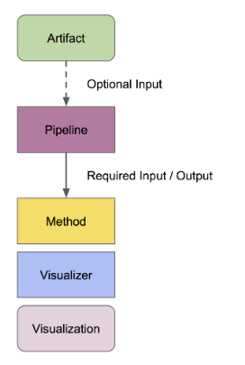

Now what is the overall process that qiime uses? Check out the flowchart:

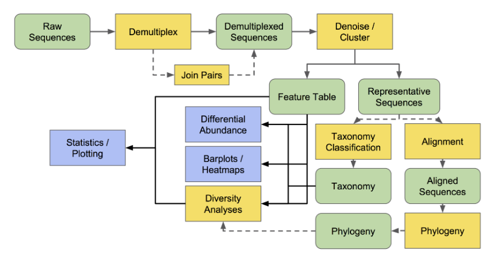

Remember, Green:Artifact, Yellow:Method, Blue:visualizer

#### Demultiplexing

The qiime process can start with one sequence file. Usually I get samples already demultiplexed by the sequencer software. You don’t have to do demultiplexing (demux) with qiime, but you can.

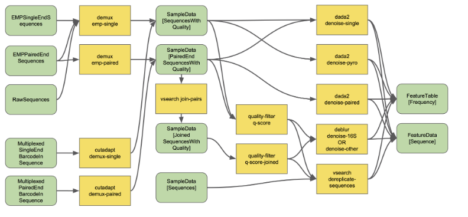

#### Denoising

This term is a blackbox to me. It just doesn’t mean much as a word. What it actually means, simply put, it is the qiime pipeline process to remove sequencing and PCR errors. These goal of these methods is to arrive at a more precise correction of sequencing errors and to avoid the preclustering step in mothur. In the end you would not be required to use 97% OTU binning, but could use what DADA2 calls amplicon sequence variants. Deblur calls them subOTUs. Basically they are OTUs clustered at 100% sequence similarity. See the DADA2 website for details on the process.

https://www.bioconductor.org/packages/devel/bioc/vignettes/dada2/inst/doc/dada2-intro.html

1. Filter and Trim
2. Dereplicate
3. Learn the error rates
4. Infer sample composition
5. Merge forward/reverse reads
6. Remove chimeras
7. Create sequence table

Follow the rest of the documentation for more details. We will discuss more next time.